# Applying multiple linear regression to estimate VO2max

Possible solutions

Jocelyn Mara PhD, University of Canberra

## Overview

This activity will provide you with the opportunity to practice building multiple linear regression models using R. This activity has been adapted from an excellent resource provided on [www.statistics.laerd.com](https://statistics.laerd.com). This site provides tutorials that are specific to the statistical software SPSS, however the concepts behind each of the statistical models are still relevant. I recommend checking out this site for more information on a range of different statistical concepts.

## The data

The data we will be using for this activity can be found in the `vo2-max_data.xlsx` file and contains data from 100 participants. It has been sourced from an excellent guide for multiple linear regression on [www.statistics.laerd.com](https://statistics.laerd.com) and consists of the following variables:

1. `subject_id`: unique subject identification number
2. `age`: subject age in years
3. `weight`: subject weight in kilograms
4. `heart_rate`: subject average heart rate in the last 5 minutes of a 20 minute submaximal cycling test
5. `gender`: 1 = male, 0 = female
6. `vo2_max`: VO2max in ml/kg/min recorded from a maximal treadmill test

Each row is one subjects data.

## Our question

This data has been captured to develop a model to estimate VO2max (response variable) based on a persons age, weight, gender and heart rate during a 20 minute submaximal cycling test (explanatory/predictor variables). This would allow future participants to not have to complete a strenuous maximal running treadmill test (which might deter some participants) and rather, to just complete a less strenuous submaximal test.

We can use multiple linear regression to develop this model.

### Step 1. Create a new repository on GitHub to store your data analysis project in.

Start by creating a new GitHub repository and name it something informative using best-practice directory naming conventions. Make sure you initiate it with a README.md file to provide a description for the repo.

### Step 2. Clone your GitHub repository to a local repository on your computer.

Set up all relevant folders and files that you will need to complete this project. For example, you might include a `data` directory to store the data in. You should also create a new R Markdown document to store all code, code output and text descriptions in to practice your literate programming skills.

### Step 3. Read in the data.

Read in and check the structure, head and tail of the data.

```r
library(tidyverse)
library(readxl)
df <- read_excel("data/vo2-max_data.xlsx")
```

```r
str(df)
```

```
## Classes 'tbl_df', 'tbl' and 'data.frame':    100 obs. of  6 variables:
##  $ subject_id: num  1 2 3 4 5 6 7 8 9 10 ...
##  $ age       : num  27 63 36 26 24 29 24 27 25 22 ...
##  $ weight    : num  70.5 50.3 87.7 89.8 103 ...
##  $ heart_rate: num  150 144 162 129 143 152 175 160 148 125 ...
##  $ gender    : num  1 0 1 0 1 0 1 0 1 0 ...
##  $ vo2_max   : num  55.8 35 42.9 28.3 40.6 ...
```

```r
head(df)
```

```
## # A tibble: 6 x 6
##   subject_id   age weight heart_rate gender vo2_max
##        <dbl> <dbl>  <dbl>      <dbl>  <dbl>   <dbl>
## 1          1    27   70.5        150      1    55.8
## 2          2    63   50.3        144      0    35
## 3          3    36   87.6        162      1    42.9
## 4          4    26   89.8        129      0    28.3
## 5          5    24  103.         143      1    40.6
## 6          6    29   77.4        152      0    33
```

```r
tail(df)
```

```
## # A tibble: 6 x 6
##   subject_id   age weight heart_rate gender vo2_max
##        <dbl> <dbl>  <dbl>      <dbl>  <dbl>   <dbl>
## 1         95    38   79.2        155      1    49.4
## 2         96    32  112.         135      1    33.7
## 3         97    33   88.1        130      1    49.2
## 4         98    35   94.1        148      1    42.0
## 5         99    48   97.5        116      1    35.2
## 6        100    51   93.8        124      1    32
```

### Step 4. Data transformation

After looking at the structure of your data, you might have noticed that `gender` is a numeric vector, however it should be a factor as it is categorical. Convert the variable `gender` to a factor variable.

```r
df$gender <- as.factor(df$gender)
```

### Step 5. Exploratory data analysis

1. Create visualisations to determine how each individual explanatory variable (`age`, `weight`, `heart_rate`, `gender`) relates to the response variable (`vo2_max`). Describe the strength and direction of each of these relationships.

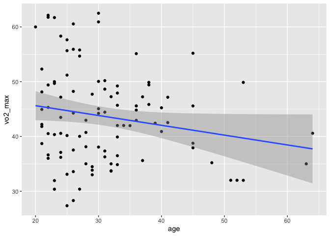

```r
# relationship between age and vo2max
ggplot(data = df, aes(x = age, y = vo2_max)) +
  geom_point() +
  geom_smooth(method = "lm")
```

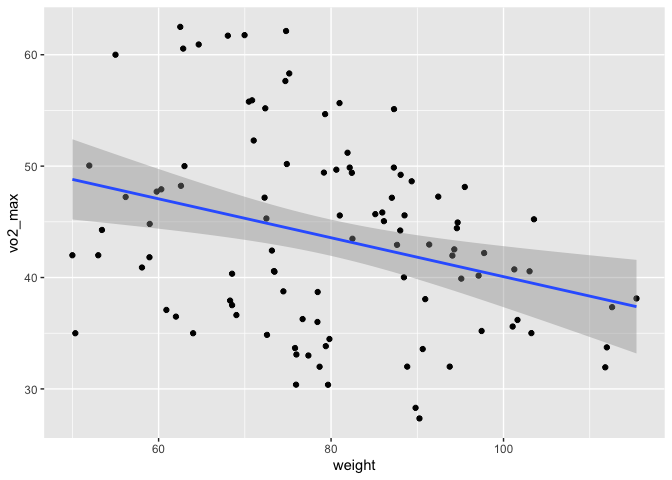

```r
# relationship between weight and vo2max
ggplot(data = df, aes(x = weight, y = vo2_max)) +
  geom_point() +
  geom_smooth(method = "lm")
```

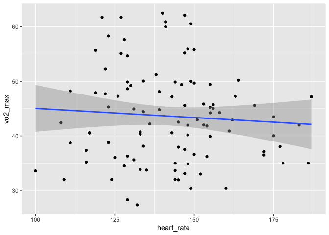

```r
# relationship between heart_rate and vo2max
ggplot(data = df, aes(x = heart_rate, y = vo2_max)) +
  geom_point() +
  geom_smooth(method = "lm")
```

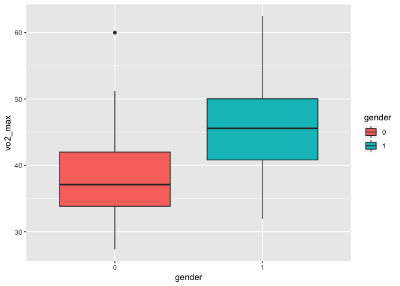

```r
# difference in vo2_max between gender
ggplot(data = df, aes(x = gender, y = vo2_max)) +
  geom_boxplot(aes(fill = gender))
```

2. Create visualisations to show how each individual continuous explanatory variable relates to `vo2_max`, but this time include `gender` as an additional variable on each visualisation. Does this provide any new insights?

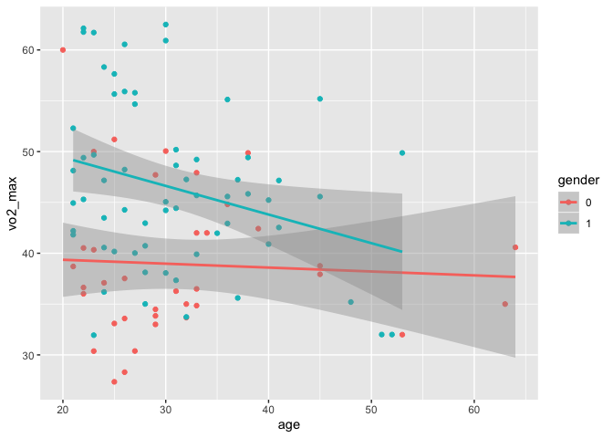

```r
# relationship between age and vo2max, with gender
ggplot(data = df, aes(x = age, y = vo2_max, colour = gender)) +
  geom_point() +
  geom_smooth(method = "lm")
```

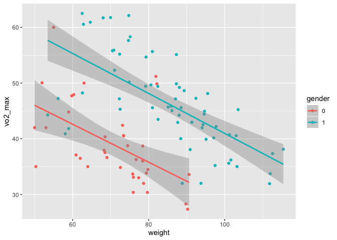

```r
# relationship between weight and vo2max, with gender
ggplot(data = df, aes(x = weight, y = vo2_max, colour = gender)) +
  geom_point() +
  geom_smooth(method = "lm")
```

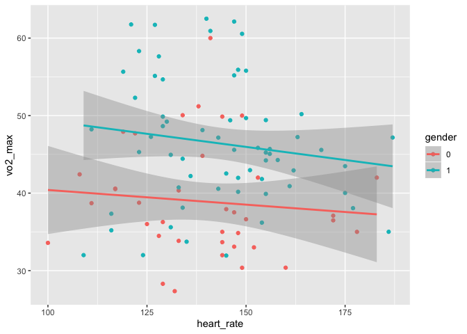

```r
# relationship between heart_rate and vo2max, with gender
ggplot(data = df, aes(x = heart_rate, y = vo2_max, colour = gender)) +
  geom_point() +
  geom_smooth(method = "lm")
```

3. The exploratory data analysis stage is a good time to conduct some preliminary investigations to check if there is any evidence of multicollinearity. Create an appropriate visualisation to check for multicollinearity and describe if there is any evidence for this.

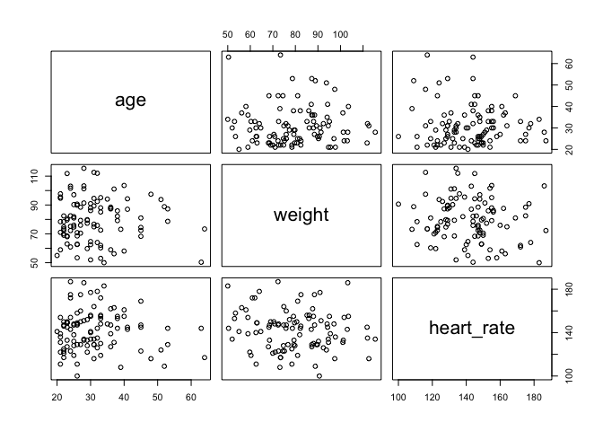

```r
pairs(formula = ~ age + weight + heart_rate, data = df)
```